# Exploring Data with R

## ggplot

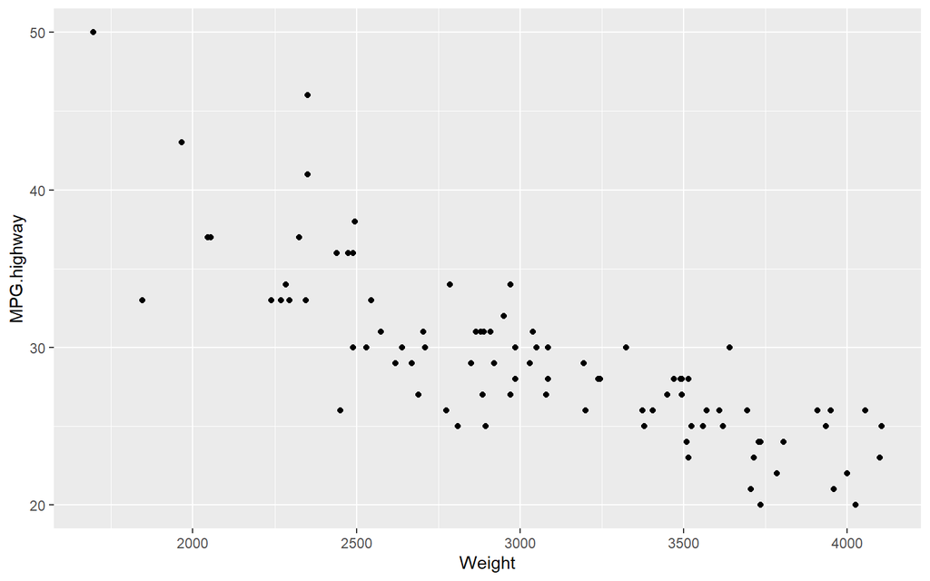

```r
library(ggplot2)

po=ggplot(Cars93,aes(x=Weight,y=MPG.highway))+
  geom_point()
po
```

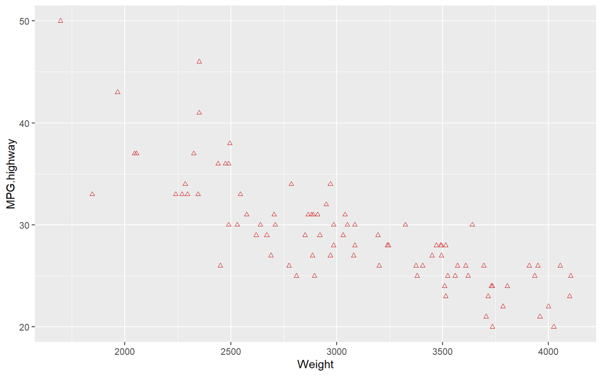

```r
p1=ggplot(Cars93,aes(x=Weight,y=MPG.highway))+
  geom_point(size=1.25,shape=2,col="red3")
p1
```

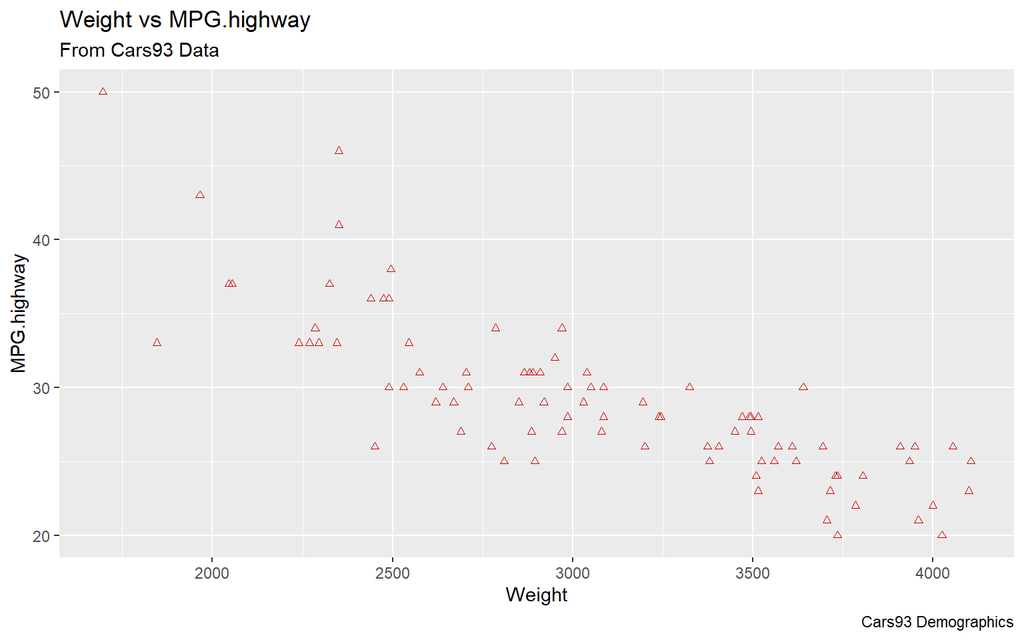

```r
p2=ggplot(Cars93,aes(x=Weight,y=MPG.highway))+
  geom_point(size=1.25,shape=2,col="red3")+
  labs(title ="Weight vs MPG.highway",subtitle = "From Cars93 Data", caption = "Cars93 Demographics")
p2
```

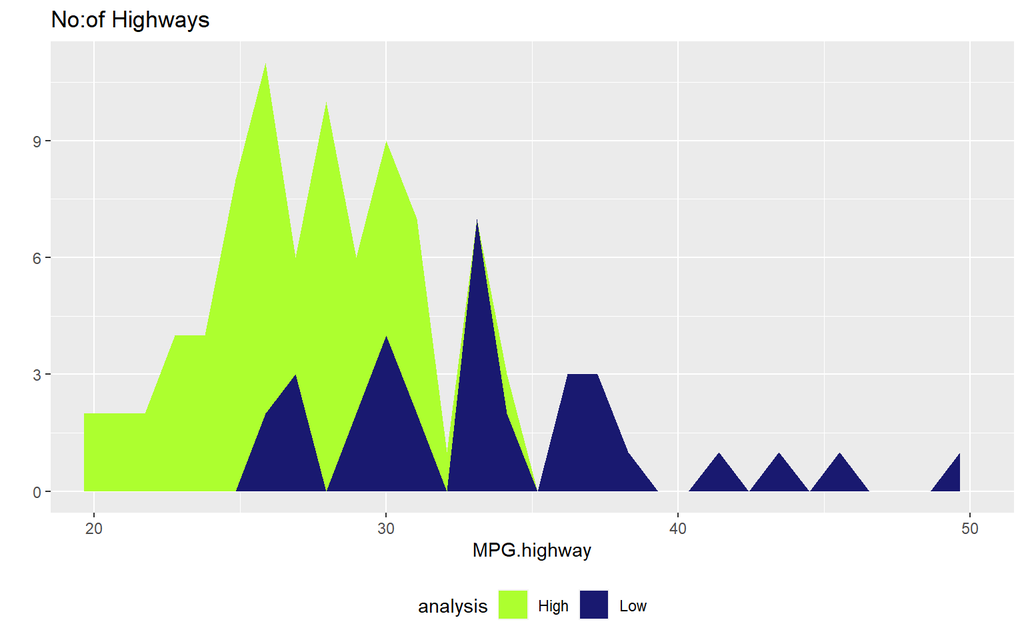

```r
p3=ggplot(newformed, aes(MPG.highway,fill=analysis)) +
  geom_area(stat = "bin",bins=30)+
  labs(title = "No:of Highways",x="MPG.highway",y="")+
  theme(legend.position = "bottom")+
  scale_fill_manual(values=c("greenyellow","midnightblue"))+
  coord_cartesian(xlim = c(20,50))
p3
```

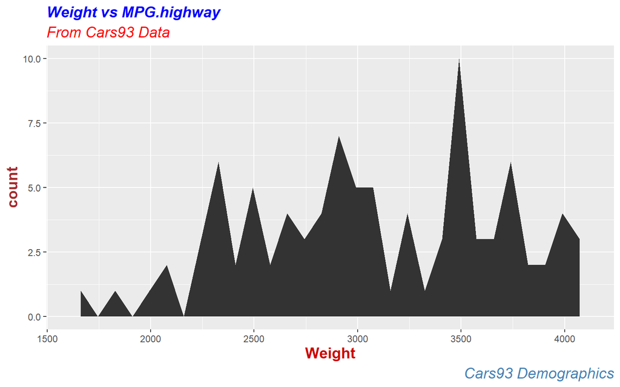

```r
p4=ggplot(Cars93,aes(x=Weight,fill=MPG.highway))+
  geom_area(stat="bin",bins=30)+
  labs(title ="Weight vs MPG.highway",subtitle = "From Cars93 Data", caption = "Cars93 Demographics")+
  theme(plot.title = element_text(color="blue", size=14, face="bold.italic"),
        plot.subtitle = element_text(color="red", size=14, face="italic"),
        axis.title.x = element_text(color="red3", size=14, face="bold"),
        axis.title.y = element_text(color="brown", size=14, face="bold"),
        plot.caption =  element_text(color="steelblue", size=14, face="italic"))
p4
```

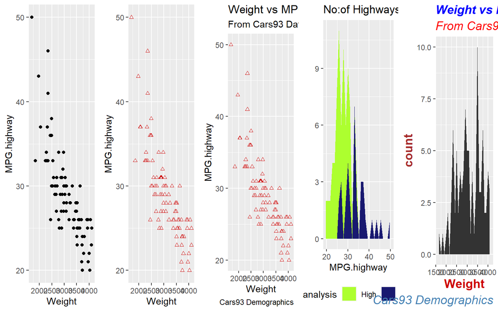

```r
p5=gridExtra::grid.arrange(po,p1,p2,p3,p4,nrow=1,ncol=5)
```

*There is a negative linear relationship between the weight and MPG.highway of cars. It takes more fuel to move a heavier car.*

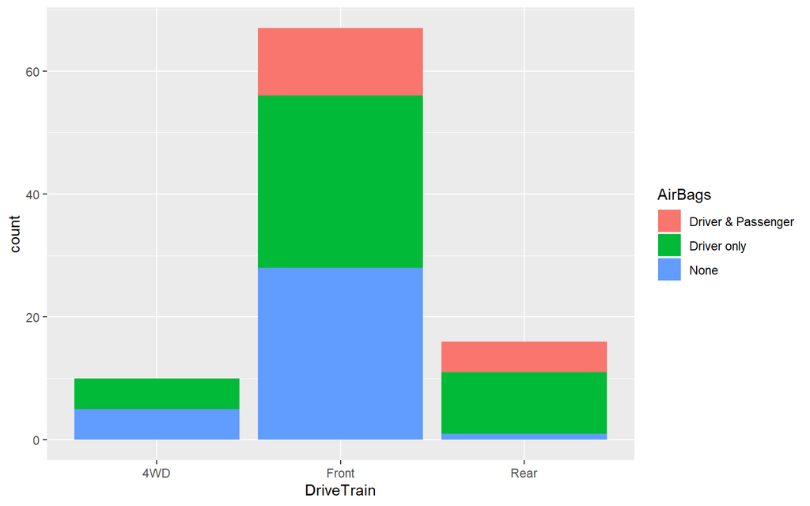

```r
m1=ggplot(Cars93,aes(x=DriveTrain,fill=AirBags))+
  geom_bar()
m1
```

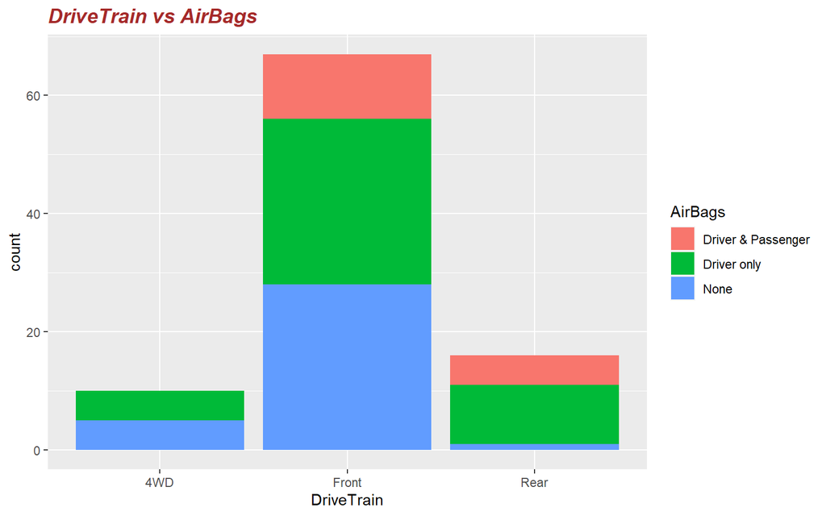

```r
m2=ggplot(Cars93,aes(x=DriveTrain,fill=AirBags))+
  geom_bar()+
  labs(title ="DriveTrain vs AirBags")+
  theme(plot.title = element_text(color="brown", size=14, face="bold.italic"))
m2
```

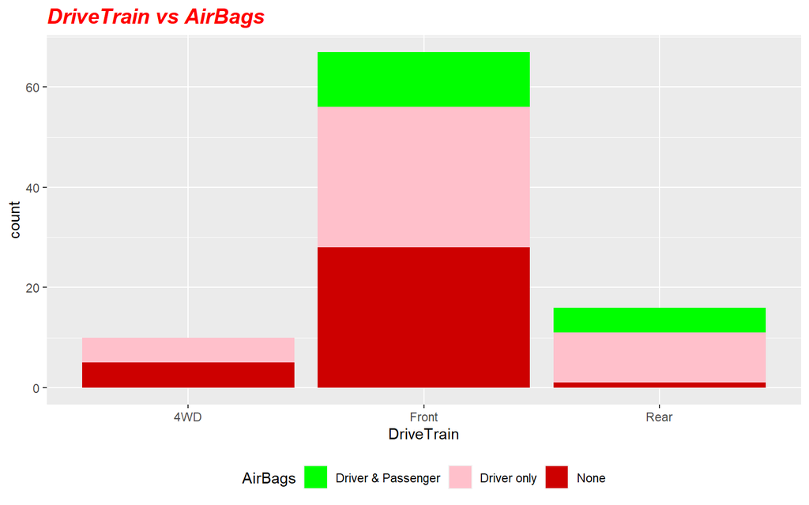

```r
m3=ggplot(Cars93,aes(x=DriveTrain,fill=AirBags))+
  geom_bar()+
  labs(title ="DriveTrain vs AirBags")+
  theme(plot.title = element_text(color="red",size=15,face="bold.italic"),legend.position = "bottom")+
  scale_fill_manual(values=c("green", "pink","red3"))
m3
```

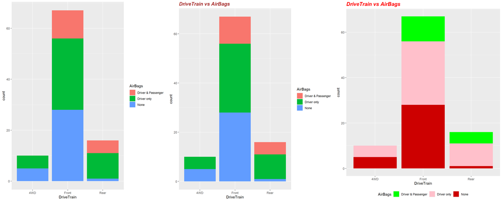

```r
m4=gridExtra::grid.arrange(m1,m2,m3,nrow=1,ncol=3)
```

## Facetting with Cars93

1 DIMENSION

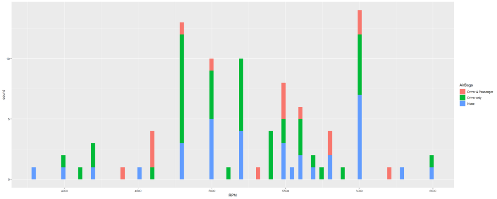

```r
b1=ggplot(Cars93,aes(x=RPM,fill=AirBags))+
  geom_histogram(stat = "bin",bins="95")
b1
```

2 DIMENSION

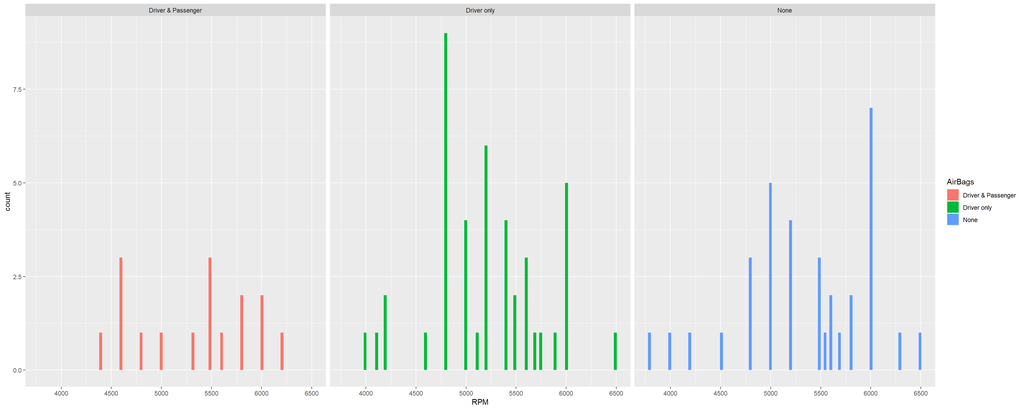

```r
b2=b1+facet_grid(~AirBags)
b2
```

3 DIMENSION

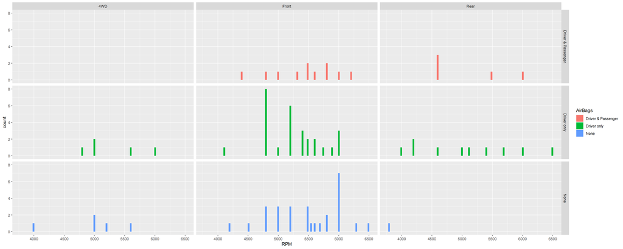

```r
b3=b1+facet_grid(AirBags~DriveTrain)
b3
```

4 DIMENSION

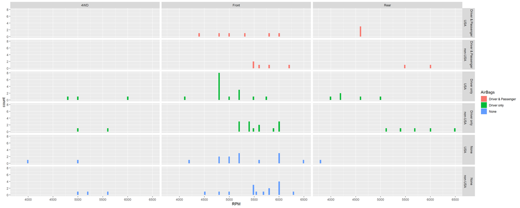

```r
b4=b1+facet_grid(AirBags+Origin~DriveTrain)
b4
```

5 DIMENSION

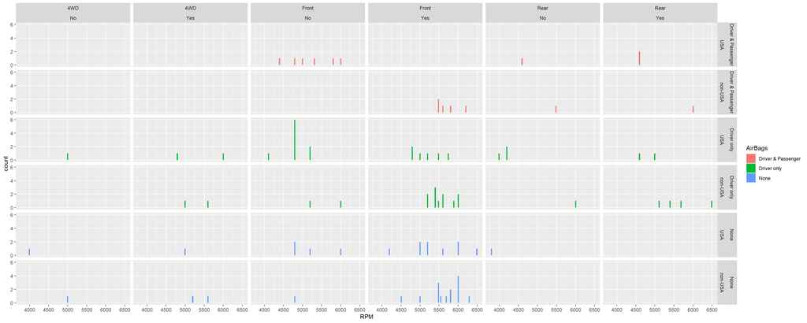

```r
b5=b1+facet_grid(AirBags+Origin~DriveTrain+Man.trans.avail)
b5
```

## Questions

### (Q1) List the names of the variables in Cars93, and also list the types of the corresponding names.

```r
names(Cars93)
```

```
##  [1] "Manufacturer"       "Model"              "Type"
##  [4] "Min.Price"          "Price"              "Max.Price"
##  [7] "MPG.city"           "MPG.highway"        "AirBags"
## [10] "DriveTrain"         "Cylinders"          "EngineSize"
## [13] "Horsepower"         "RPM"                "Rev.per.mile"
## [16] "Man.trans.avail"    "Fuel.tank.capacity" "Passengers"
## [19] "Length"             "Wheelbase"          "Width"
## [22] "Turn.circle"        "Rear.seat.room"     "Luggage.room"
## [25] "Weight"             "Origin"             "Make"
```

```r
sapply(Cars93,typeof)
```

```
##       Manufacturer              Model               Type          Min.Price
##          "integer"          "integer"          "integer"           "double"
##              Price          Max.Price           MPG.city        MPG.highway
##           "double"           "double"          "integer"          "integer"
##            AirBags         DriveTrain          Cylinders         EngineSize
##          "integer"          "integer"          "integer"           "double"
##         Horsepower                RPM       Rev.per.mile    Man.trans.avail
##          "integer"          "integer"          "integer"          "integer"
## Fuel.tank.capacity         Passengers             Length          Wheelbase
##           "double"          "integer"          "integer"          "integer"
##              Width        Turn.circle     Rear.seat.room       Luggage.room
##          "integer"          "integer"           "double"          "integer"
##             Weight             Origin               Make
##          "integer"          "integer"          "integer"
```

```r
str(Cars93)
```

```
## 'data.frame':    93 obs. of  27 variables:
##  $ Manufacturer      : Factor w/ 32 levels "Acura","Audi",..: 1 1 2 2 3 4 4 4 4 5 ...
##  $ Model             : Factor w/ 93 levels "100","190E","240",..: 49 56 9 1 6 24 54 74 73 35 ...
##  $ Type              : Factor w/ 6 levels "Compact","Large",..: 4 3 1 3 3 3 2 2 3 2 ...
##  $ Min.Price         : num  12.9 29.2 25.9 30.8 23.7 14.2 19.9 22.6 26.3 33 ...
##  $ Price             : num  15.9 33.9 29.1 37.7 30 15.7 20.8 23.7 26.3 34.7 ...
##  $ Max.Price         : num  18.8 38.7 32.3 44.6 36.2 17.3 21.7 24.9 26.3 36.3 ...
##  $ MPG.city          : int  25 18 20 19 22 22 19 16 19 16 ...
##  $ MPG.highway       : int  31 25 26 26 30 31 28 25 27 25 ...
##  $ AirBags           : Factor w/ 3 levels "Driver & Passenger",..: 3 1 2 1 2 2 2 2 2 2 ...
##  $ DriveTrain        : Factor w/ 3 levels "4WD","Front",..: 2 2 2 2 3 2 2 3 2 2 ...
##  $ Cylinders         : Factor w/ 6 levels "3","4","5","6",..: 2 4 4 4 2 2 4 4 4 5 ...
##  $ EngineSize        : num  1.8 3.2 2.8 2.8 3.5 2.2 3.8 5.7 3.8 4.9 ...
##  $ Horsepower        : int  140 200 172 172 208 110 170 180 170 200 ...
##  $ RPM               : int  6300 5500 5500 5500 5700 5200 4800 4000 4800 4100 ...
##  $ Rev.per.mile      : int  2890 2335 2280 2535 2545 2565 1570 1320 1690 1510 ...
##  $ Man.trans.avail   : Factor w/ 2 levels "No","Yes": 2 2 2 2 2 1 1 1 1 1 ...
##  $ Fuel.tank.capacity: num  13.2 18 16.9 21.1 21.1 16.4 18 23 18.8 18 ...
##  $ Passengers        : Factor w/ 6 levels "2","4","5","6",..: 3 3 3 4 2 4 4 4 3 4 ...
##  $ Length            : int  177 195 180 193 186 189 200 216 198 206 ...
##  $ Wheelbase         : int  102 115 102 106 109 105 111 116 108 114 ...
##  $ Width             : int  68 71 67 70 69 69 74 78 73 73 ...
##  $ Turn.circle       : int  37 38 37 37 39 41 42 45 41 43 ...
##  $ Rear.seat.room    : num  26.5 30 28 31 27 28 30.5 30.5 26.5 35 ...
##  $ Luggage.room      : int  11 15 14 17 13 16 17 21 14 18 ...
##  $ Weight            : int  2705 3560 3375 3405 3640 2880 3470 4105 3495 3620 ...
##  $ Origin            : Factor w/ 2 levels "USA","non-USA": 2 2 2 2 2 1 1 1 1 1 ...
##  $ Make              : Factor w/ 93 levels "Acura Integra",..: 1 2 4 3 5 6 7 9 8 10 ...
```

### (Q2) Find the number of vehicles for each Type of Car

```r
table(Cars93$Type)
```

```
##
## Compact   Large Midsize   Small  Sporty     Van
##      16      11      22      21      14       9
```

### (Q3) Find the number of rows and columns

```r
nrow(Cars93)
```

```
## [1] 93
```

```r
ncol(Cars93)
```

```
## [1] 27
```

### (Q4) Show the first few rows and the last few rows of the dataset

First few rows

```r
head(Cars93)
```

```
##   Manufacturer   Model    Type Min.Price Price Max.Price MPG.city MPG.highway
## 1        Acura Integra   Small      12.9  15.9      18.8       25          31
## 2        Acura  Legend Midsize      29.2  33.9      38.7       18          25
## 3         Audi      90 Compact      25.9  29.1      32.3       20          26
## 4         Audi     100 Midsize      30.8  37.7      44.6       19          26
## 5          BMW    535i Midsize      23.7  30.0      36.2       22          30
## 6        Buick Century Midsize      14.2  15.7      17.3       22          31
##              AirBags DriveTrain Cylinders EngineSize Horsepower  RPM
## 1               None      Front         4        1.8        140 6300
## 2 Driver & Passenger      Front         6        3.2        200 5500
## 3        Driver only      Front         6        2.8        172 5500
## 4 Driver & Passenger      Front         6        2.8        172 5500
## 5        Driver only       Rear         4        3.5        208 5700
## 6        Driver only      Front         4        2.2        110 5200
##   Rev.per.mile Man.trans.avail Fuel.tank.capacity Passengers Length Wheelbase
## 1         2890             Yes               13.2          5    177       102
## 2         2335             Yes               18.0          5    195       115
## 3         2280             Yes               16.9          5    180       102
## 4         2535             Yes               21.1          6    193       106
## 5         2545             Yes               21.1          4    186       109
## 6         2565              No               16.4          6    189       105
##   Width Turn.circle Rear.seat.room Luggage.room Weight  Origin          Make
## 1    68          37           26.5           11   2705 non-USA Acura Integra
## 2    71          38           30.0           15   3560 non-USA  Acura Legend
## 3    67          37           28.0           14   3375 non-USA       Audi 90
## 4    70          37           31.0           17   3405 non-USA      Audi 100
## 5    69          39           27.0           13   3640 non-USA      BMW 535i
## 6    69          41           28.0           16   2880     USA Buick Century
```

Alternatively,

```r
Cars93[1:6,]
```

```
##   Manufacturer   Model    Type Min.Price Price Max.Price MPG.city MPG.highway
## 1        Acura Integra   Small      12.9  15.9      18.8       25          31
## 2        Acura  Legend Midsize      29.2  33.9      38.7       18          25
## 3         Audi      90 Compact      25.9  29.1      32.3       20          26
## 4         Audi     100 Midsize      30.8  37.7      44.6       19          26
## 5          BMW    535i Midsize      23.7  30.0      36.2       22          30
## 6        Buick Century Midsize      14.2  15.7      17.3       22          31
##              AirBags DriveTrain Cylinders EngineSize Horsepower  RPM
## 1               None      Front         4        1.8        140 6300
## 2 Driver & Passenger      Front         6        3.2        200 5500
## 3        Driver only      Front         6        2.8        172 5500
## 4 Driver & Passenger      Front         6        2.8        172 5500
## 5        Driver only       Rear         4        3.5        208 5700
## 6        Driver only      Front         4        2.2        110 5200
##   Rev.per.mile Man.trans.avail Fuel.tank.capacity Passengers Length Wheelbase
## 1         2890             Yes               13.2          5    177       102
## 2         2335             Yes               18.0          5    195       115
## 3         2280             Yes               16.9          5    180       102
## 4         2535             Yes               21.1          6    193       106
## 5         2545             Yes               21.1          4    186       109
## 6         2565              No               16.4          6    189       105
##   Width Turn.circle Rear.seat.room Luggage.room Weight  Origin          Make
## 1    68          37           26.5           11   2705 non-USA Acura Integra
## 2    71          38           30.0           15   3560 non-USA  Acura Legend
## 3    67          37           28.0           14   3375 non-USA       Audi 90
## 4    70          37           31.0           17   3405 non-USA      Audi 100
## 5    69          39           27.0           13   3640 non-USA      BMW 535i
## 6    69          41           28.0           16   2880     USA Buick Century
```

Last few rows

```r
Cars93[88:93,]
```

```
##    Manufacturer   Model    Type Min.Price Price Max.Price MPG.city MPG.highway
## 88   Volkswagen     Fox   Small       8.7   9.1       9.5       25          33
## 89   Volkswagen Eurovan     Van      16.6  19.7      22.7       17          21
## 90   Volkswagen  Passat Compact      17.6  20.0      22.4       21          30
## 91   Volkswagen Corrado  Sporty      22.9  23.3      23.7       18          25
## 92        Volvo     240 Compact      21.8  22.7      23.5       21          28
## 93        Volvo     850 Midsize      24.8  26.7      28.5       20          28
##               AirBags DriveTrain Cylinders EngineSize Horsepower  RPM
## 88               None      Front         4        1.8         81 5500
## 89               None      Front         5        2.5        109 4500
## 90               None      Front         4        2.0        134 5800
## 91               None      Front         6        2.8        178 5800
## 92        Driver only       Rear         4        2.3        114 5400
## 93 Driver & Passenger      Front         5        2.4        168 6200
##    Rev.per.mile Man.trans.avail Fuel.tank.capacity Passengers Length Wheelbase
```

[output cut: 20 more lines]

Alternatively,

```r
tail(Cars93)
```

```
##    Manufacturer   Model    Type Min.Price Price Max.Price MPG.city MPG.highway
## 88   Volkswagen     Fox   Small       8.7   9.1       9.5       25          33
## 89   Volkswagen Eurovan     Van      16.6  19.7      22.7       17          21
## 90   Volkswagen  Passat Compact      17.6  20.0      22.4       21          30
## 91   Volkswagen Corrado  Sporty      22.9  23.3      23.7       18          25
## 92        Volvo     240 Compact      21.8  22.7      23.5       21          28
## 93        Volvo     850 Midsize      24.8  26.7      28.5       20          28
##               AirBags DriveTrain Cylinders EngineSize Horsepower  RPM
## 88               None      Front         4        1.8         81 5500
## 89               None      Front         5        2.5        109 4500
## 90               None      Front         4        2.0        134 5800
## 91               None      Front         6        2.8        178 5800
## 92        Driver only       Rear         4        2.3        114 5400
## 93 Driver & Passenger      Front         5        2.4        168 6200
##    Rev.per.mile Man.trans.avail Fuel.tank.capacity Passengers Length Wheelbase
```

[output cut: 20 more lines]

### (Q5) Extract the nonUS models and US models of cars and save them to the corresponding US, and nonUS variables.

```r
USA_Models=Cars93[Cars93$Origin=="USA",]
View(USA_Models)
Non_USA_Models=Cars93[Cars93$Origin=="non-USA",]
View(Non_USA_Models)
table(Cars93$Origin, Cars93$Type)
```

```
##
##           Compact Large Midsize Small Sporty Van
##   USA           7    11      10     7      8   5
##   non-USA       9     0      12    14      6   4
```

### (Q6) Show a five-number summary for fuel tank capacity.

```r
summary(Cars93$Fuel.tank.capacity)
```

```
##    Min. 1st Qu.  Median    Mean 3rd Qu.    Max.
##    9.20   14.50   16.40   16.66   18.80   27.00
```

```r
fivenum(Cars93$Fuel.tank.capacity)
```

```
## [1]  9.2 14.5 16.4 18.8 27.0
```

### (Q7) Draw a box plot for fuel tank capacity

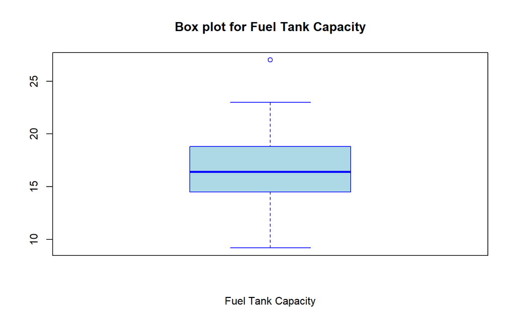

```r
boxplot(Cars93$Fuel.tank.capacity,main="Box plot for Fuel Tank Capacity",xlab="Fuel Tank Capacity",col="lightblue", border="blue")
```

### (Q8) Make a bar plot for the number of cylinders of cars

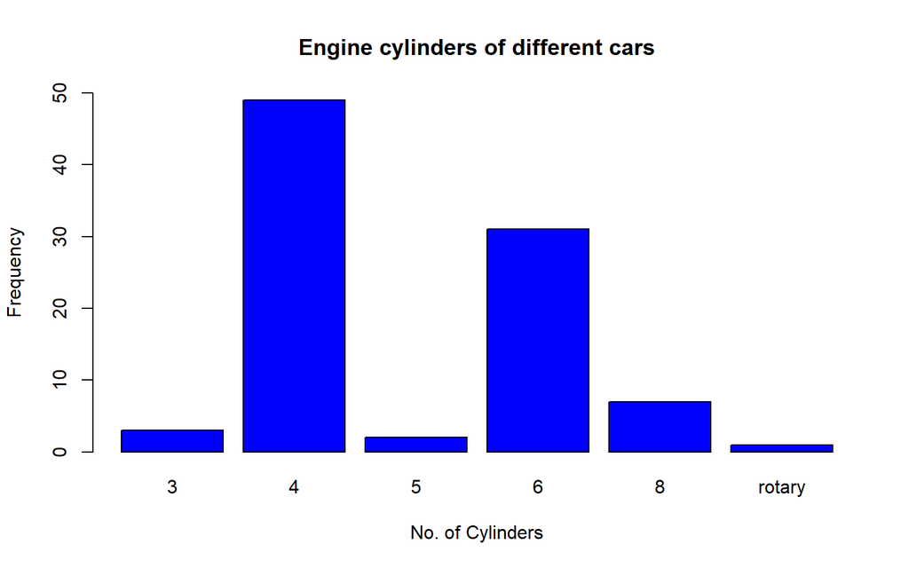

```r
barplot(table(Cars93$Cylinders),ylim=c(0,50),col="blue",main="Engine cylinders of different cars",xlab="No. of Cylinders", ylab="Frequency")
```

Alternatively,

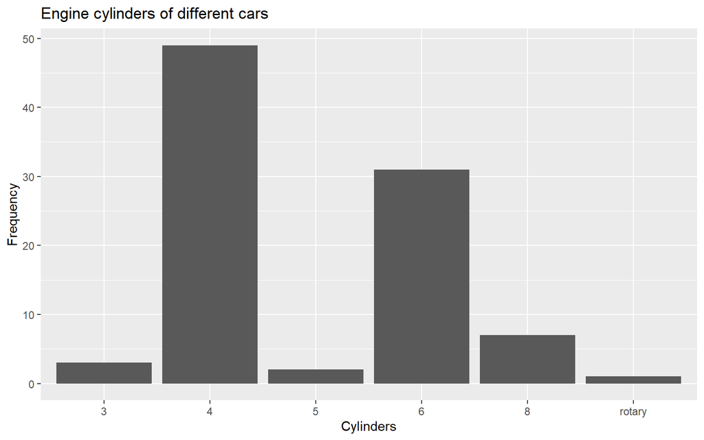

```r
library(ggplot2)
ggplot(Cars93,aes(x=Cylinders))+
  geom_bar()+
  labs(y="Frequency", title="Engine cylinders of different cars")
```

### (Q9) Plot the city MPG vs the highway MPG

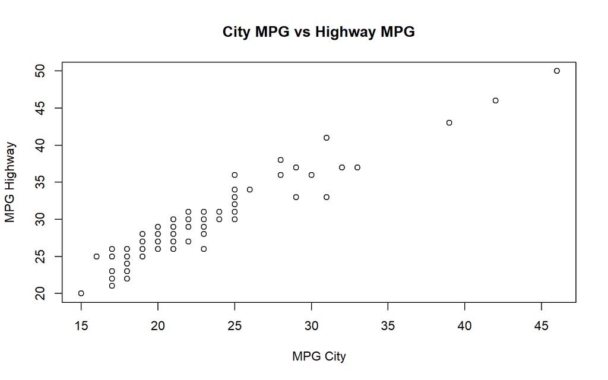

```r
plot(Cars93$MPG.city,Cars93$MPG.highway,main="City MPG vs Highway MPG",xlab="MPG City",ylab="MPG Highway")
```

### (Q10) Draw a histogram for min prices.

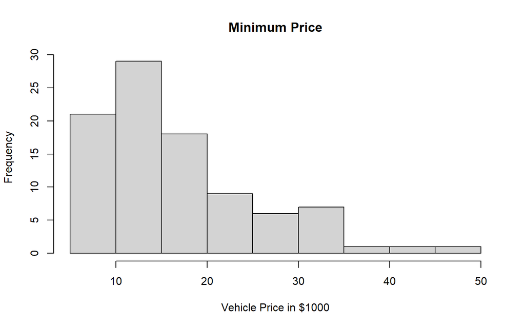

```r
hist(Cars93$Min.Price,main="Minimum Price",xlab="Vehicle Price in $1000")
```

### (Q11) Find the cheapest car in each type

The Type variable classifies the type of market the car is aimed at.

```r
table(Cars93$Type)
```

```
##
## Compact   Large Midsize   Small  Sporty     Van
##      16      11      22      21      14       9
```

```r
C=Cars93[Cars93$Type=="Compact","Min.Price"]

min(C)
```

```
## [1] 8.5
```

```r
L=Cars93[Cars93$Type=="Large","Min.Price"]

min(L)
```

```
## [1] 17.5
```

```r
M=Cars93[Cars93$Type=="Midsize","Min.Price"]

min(M)
```

```
## [1] 12.4
```

```r
S=Cars93[Cars93$Type=="Small","Min.Price"]

min(S)
```

```
## [1] 6.7
```

```r
Sp=Cars93[Cars93$Type=="Sporty","Min.Price"]

min(Sp)
```

```
## [1] 9.1
```

```r
V=Cars93[Cars93$Type=="Van","Min.Price"]

min(V)
```

```
## [1] 13.6
```

Alternatively, tapply function can be used

```r
?tapply

tapply(Cars93$Min.Price, INDEX=Cars93$Type,FUN=min)
```

```
## Compact   Large Midsize   Small  Sporty     Van
##     8.5    17.5    12.4     6.7     9.1    13.6
```

### (Q12) Create a bar plot of Type in the Cars 93 dataframe.

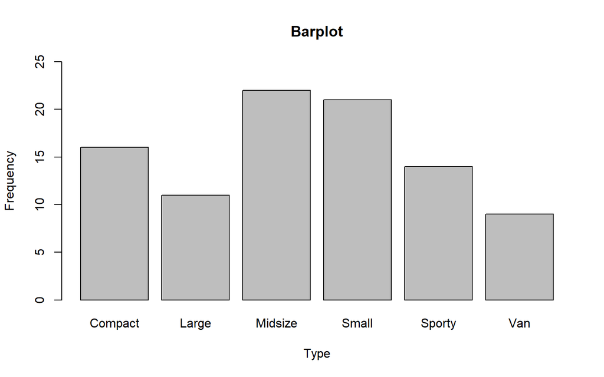

```r
barplot(table(Cars93$Type),ylim=c(0,25),main="Barplot",xlab="Type",ylab="Frequency")
```

### (Q13) Find the car with the greatest fuel efficiency

The EPA ratings are the number one thing that can be used to figure out which cars are more fuel efficient than their competitors. EPA rating for a vehicle’s average fuel economy (EPA combined) is the split between highway and city driving.The EPA rating for combined mpg presumes that we drive 55 percent of the time in the city and 45 percent of the time on the highway.

```r
A=tapply(Cars93$MPG.city, INDEX=Cars93$Model)
B=tapply(Cars93$MPG.highway, INDEX=Cars93$Model)
A=Cars93$MPG.city
B=Cars93$MPG.highway
EPA_ratings= A*(55/100)+B*(45/100)
newformed2=cbind(newformed,EPA_ratings)
View(newformed2)
max(newformed2$EPA_ratings)
```

```
## [1] 47.8
```

**Geo Metro achieves fuel economy of 46 mpg city and 50 mpg highway.Therefore the most fuel efficient car is Geo Metro with EPA rating 47.8**

### (Q14) Compute the mean horsepower for Compact and Large types of Car, and the difference between each cars horsepower and the mean for its type

```r
Cars93[Cars93$Type == "Compact",]$Horsepower - mean(Cars93[Cars93$Type=="Compact",]$Horsepower)
```

```
##  [1]  41 -21 -21  10 -31 -35   9  33  -1  19  24 -21   9  -1   3 -17
```

```r
Cars93[Cars93$Type == "Large",]$Horsepower - mean(Cars93[Cars93$Type=="Large",]$Horsepower)
```

```
##  [1]  -9.4545455   0.5454545  20.5454545  -9.4545455 -26.4545455 -32.4545455
##  [7]  34.5454545  10.5454545  30.5454545  -9.4545455  -9.4545455
```

### (Q15) What is the absolute difference between the average horsepower of 4-cylinder cars and the average horsepower of 8-cylinder cars?

```r
mean(Cars93[Cars93$Cylinders == "8",]$Horsepower) - mean(Cars93[Cars93$Cylinders == "4",]$Horsepower)
```

```
## [1] 121.2449
```

### (Q16) Find the number of 4-cylinder USA cars

```r
sum(Cars93$Origin == "USA" & Cars93$Cylinders == 4)
```

```
## [1] 22
```

### (Q17) Create a table to summarize the AirBags variable

```r
table(Cars93$AirBags)
```

```
##
## Driver & Passenger        Driver only               None
##                 16                 43                 34
```

### (Q18) Create a pie chart to visualize the AirBags variable. Use different colors to represent each category.

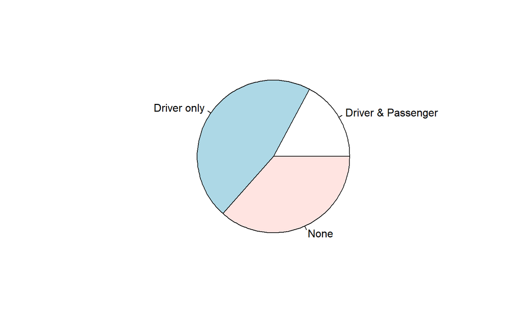

```r
pie(table(Cars93$AirBags))
```

### (Q19) Create a 3D pie chart to visualize the AirBags variable. Use different colors to represent each category.

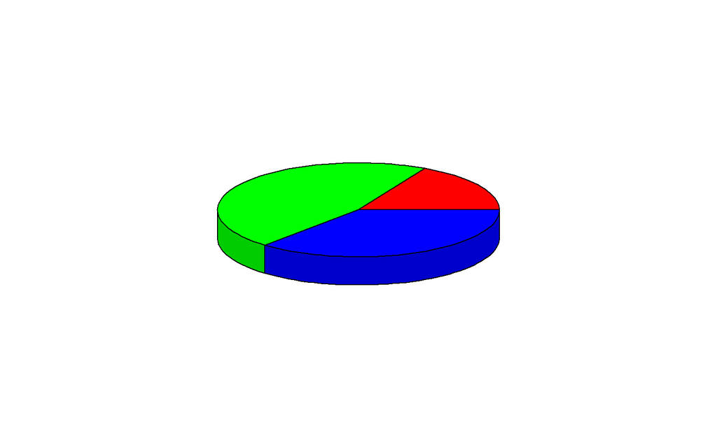

```r
library(plotrix)

pie3D(table(Cars93$AirBags))
```

### (Q20) Create a table to summarize the Type variable.

```r
table(Cars93$Type)
```

```
##
## Compact   Large Midsize   Small  Sporty     Van
##      16      11      22      21      14       9
```

### (Q21) Create a bar graph to visualize the Type variable. Use different colors to represent each category.

```r
table(Cars93$Type)
```

```
##
## Compact   Large Midsize   Small  Sporty     Van
##      16      11      22      21      14       9
```

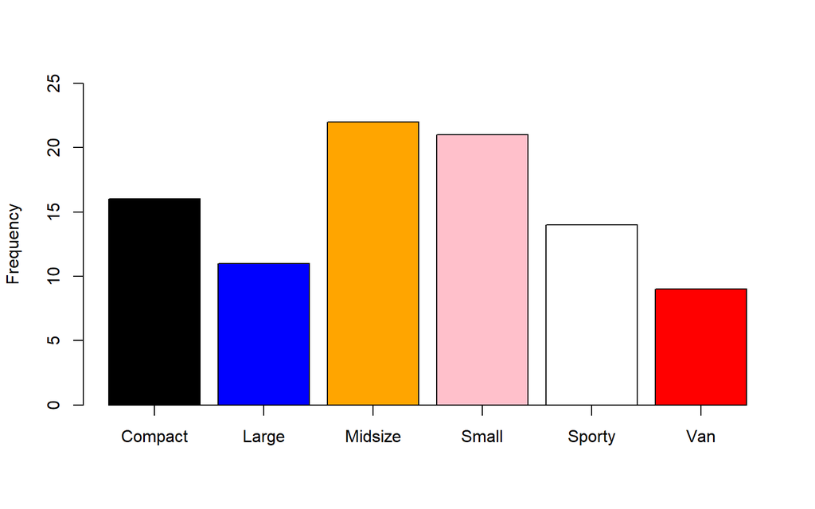

```r
color.names = c("black","blue","orange","pink","white","red")

barplot(table(Cars93$Type),ylim = c(0,25),ylab="Frequency",axis.lty="solid",space=.20,col=color.names)
```

### (Q22) Create a table to summarize two categorical variables; AirBags and Origin.

```r
table(Cars93$AirBags, Cars93$Origin)
```

```
##
##                      USA non-USA
##   Driver & Passenger   9       7
##   Driver only         23      20
##   None                16      18
```

### (Q23) Create a grouped bar graph with AirBags and Origin variables. Use different colors.

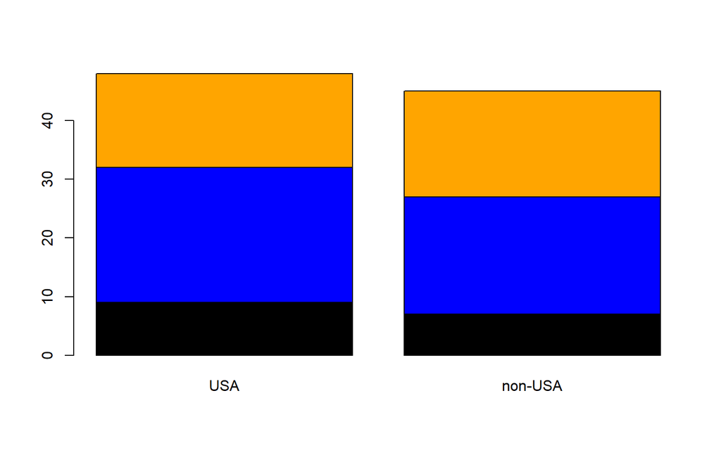

```r
color.names = c("black","blue","orange")

barplot(table(Cars93$AirBags, Cars93$Origin), space=.20, col=color.names)
```

### (Q24) Create a table to summarize two categorical variables;Type and DriveTrain.

```r
table(Cars93$Type, Cars93$DriveTrain)
```

```
##
##           4WD Front Rear
##   Compact   1    13    2
##   Large     0     7    4
##   Midsize   0    17    5
##   Small     2    19    0
##   Sporty    2     7    5
##   Van       5     4    0
```

### (Q25) Create a grouped bar graph with Type and DriveTrain variables.Use different colors and legend to make the plot as descriptive as possible.

```r
table(Cars93$Type, Cars93$DriveTrain)
```

```
##
##           4WD Front Rear
##   Compact   1    13    2
##   Large     0     7    4
##   Midsize   0    17    5
##   Small     2    19    0
##   Sporty    2     7    5
##   Van       5     4    0
```

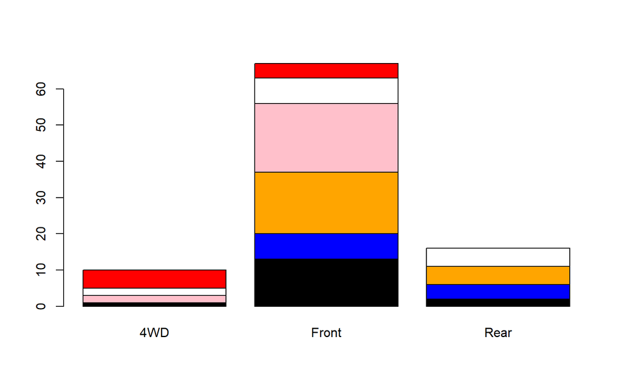

```r
color.names = c("black","blue","orange","pink","white","red")

barplot(table(Cars93$Type, Cars93$DriveTrain), space=.20, col=color.names)
```

### (Q26) Explore the relationship between MPG and horsepower. Is there a different relationship for USA models and non-USA models?

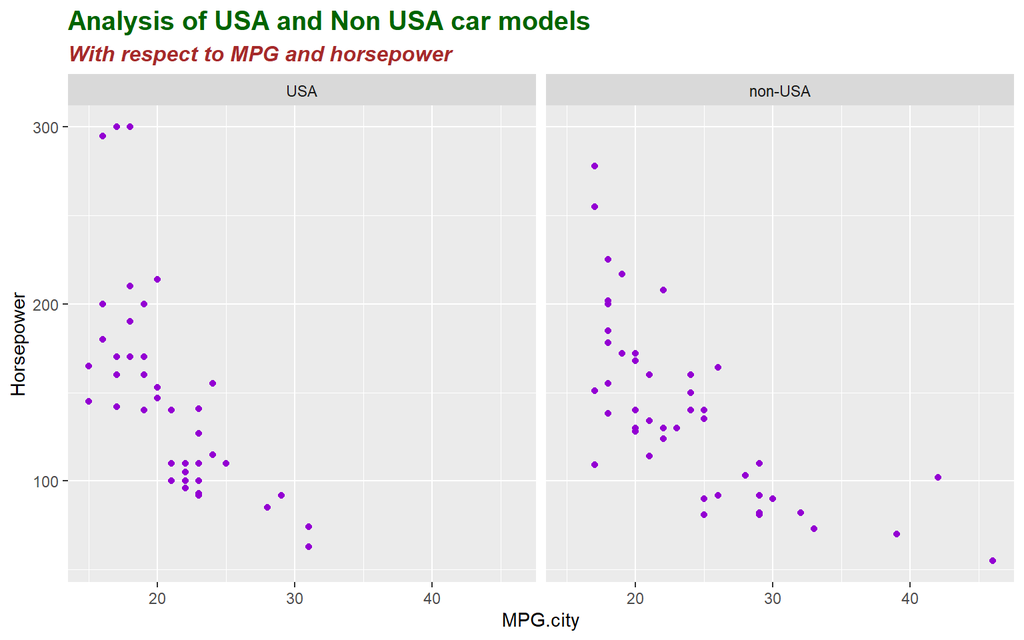

```r
ggplot(Cars93, aes(x=MPG.city,y= Horsepower)) +
  geom_point(color="darkviolet") +
  labs(title = "Analysis of USA and Non USA car models",
       subtitle = ("With respect to MPG and horsepower"))+
  theme(plot.title = element_text(face = "bold", color = "darkgreen",
                                  size = 15),
        plot.subtitle = element_text(face = "bold.italic", color = "brown",
                                     size = 12))+
  facet_grid(~Origin)
```

If we want Cars with high Horsepower (i.e around 300 Horsepower) then it is recommended to buy a USA car model. But if we want High MPG, then we have more choices among Non USA models.

## Univariate Analysis

```r
W=Cars93$Weight
mean(W)
```

```
## [1] 3072.903
```

```r
sd(W)
```

```
## [1] 589.8965
```

```r
var(W)
```

```
## [1] 347977.9
```

```r
mode(W)
```

```
## [1] "numeric"
```

```r
min(W)
```

```
## [1] 1695
```

```r
max(W)
```

```
## [1] 4105
```

```r
range(W)
```

```
## [1] 1695 4105
```

`Median,Quartiles and Percentiles`

MEDIAN

```r
median(W)
```

```
## [1] 3040
```

FIRST QUARTILE

```r
quantile(W,0.25)
```

```
##  25%
## 2620
```

SECOND QUARTILE- MEDIAN

```r
quantile(W,0.5)
```

```
##  50%
## 3040
```

THIRD QUARTILE

```r
quantile(W,0.75)
```

```
##  75%
## 3525
```

60TH PERCENTILE

```r
quantile(W,0.6)
```

```
##  60%
## 3261
```

SPECIFIC PERCENTILES

```r
quantile(W,c(0.4,0.6,0.80,1))
```

```
##  40%  60%  80% 100%
## 2894 3261 3632 4105
```

PERCENTILES IN SEQUENCE

```r
quantile(W,seq(0,1,0.2))
```

```
##   0%  20%  40%  60%  80% 100%
## 1695 2492 2894 3261 3632 4105
```

SUMMARY OF VARIABLE WEIGHT

```r
summary(W)
```

```
##    Min. 1st Qu.  Median    Mean 3rd Qu.    Max.
##    1695    2620    3040    3073    3525    4105
```

t.test

```r
ttest1<-t.test(Cars93$MPG.highway, mu=25, conf.level = 0.95)
ttest1
```

```
##
##  One Sample t-test
##
## data:  Cars93$MPG.highway
## t = 7.3905, df = 92, p-value = 6.535e-11
## alternative hypothesis: true mean is not equal to 25
## 95 percent confidence interval:
##  27.98797 30.18408
## sample estimates:
## mean of x
##  29.08602
```

Graphical

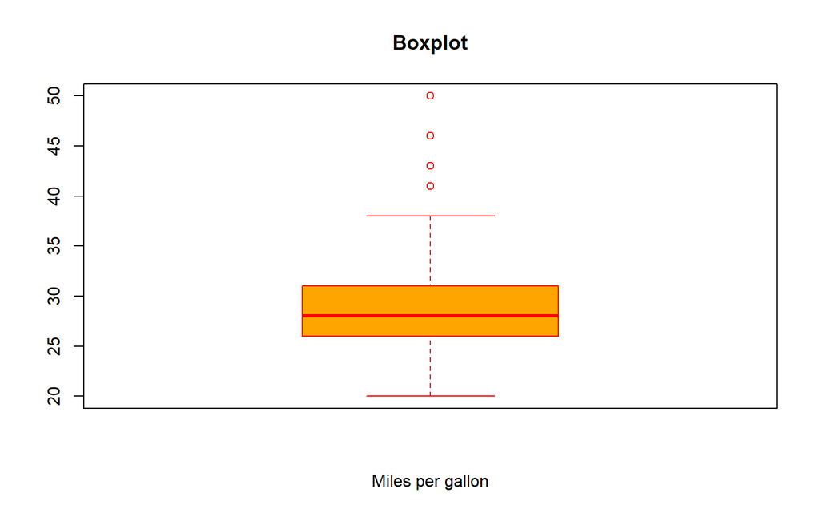

```r
B1<- boxplot(Cars93$MPG.highway, col = "orange", main = "Boxplot", border = "red",
            xlab = "Miles per gallon")
```

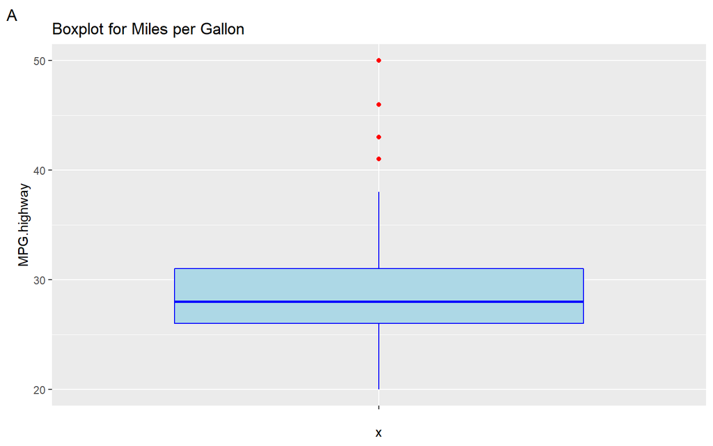

```r
GB1<- ggplot(data=Cars93, aes(x="", y=MPG.highway))+
  geom_boxplot(outlier.colour = "red", color = "Blue", fill = "lightblue")+
  labs(title="Boxplot for Miles per Gallon",tag="A")
GB1
```

## Bivariate Analysis

```r
M1<-aggregate(MPG.highway~Passengers, Cars93, quantile)
M1
```

```
##   Passengers MPG.highway.0% MPG.highway.25% MPG.highway.50% MPG.highway.75%
## 1          2           25.0            25.0            25.0            25.0
## 2          4           23.0            28.5            31.0            36.5
## 3          5           22.0            27.0            30.0            33.0
## 4          6           25.0            26.0            27.0            28.0
## 5          7           20.0            21.0            22.5            23.0
## 6          8           20.0            20.0            20.0            20.0
##   MPG.highway.100%
## 1             25.0
## 2             50.0
## 3             38.0
## 4             31.0
## 5             24.0
## 6             20.0
```

Percentile

```r
P1<- tapply(Cars93$MPG.highway, Cars93$Passengers, quantile)
P1
```

```
## $`2`
##   0%  25%  50%  75% 100%
##   25   25   25   25   25
##
## $`4`
##   0%  25%  50%  75% 100%
## 23.0 28.5 31.0 36.5 50.0
##
## $`5`
##   0%  25%  50%  75% 100%
##   22   27   30   33   38
##
## $`6`
##   0%  25%  50%  75% 100%
##   25   26   27   28   31
##
## $`7`
##   0%  25%  50%  75% 100%
## 20.0 21.0 22.5 23.0 24.0
##
## $`8`
##   0%  25%  50%  75% 100%
##   20   20   20   20   20
```

```r
cor(Cars93$Weight,Cars93$MPG.highway)
```

```
## [1] -0.8106581
```

```r
cor.test(Cars93$Weight,Cars93$MPG.highway)
```

```
##
##  Pearson's product-moment correlation
##
## data:  Cars93$Weight and Cars93$MPG.highway
## t = -13.207, df = 91, p-value < 2.2e-16
## alternative hypothesis: true correlation is not equal to 0
## 95 percent confidence interval:
##  -0.8705978 -0.7270059
## sample estimates:
##        cor
## -0.8106581
```

```r
t.test(Price~Origin,data=Cars93)
```

```
##
##  Welch Two Sample t-test
##
## data:  Price by Origin
## t = -0.95449, df = 77.667, p-value = 0.3428
## alternative hypothesis: true difference in means between group USA and group non-USA is not equal to 0
## 95 percent confidence interval:
##  -5.974255  2.102311
## sample estimates:
##     mean in group USA mean in group non-USA
##              18.57292              20.50889
```

```r
t.test(Cars93$MPG.highway~Cars93$Man.trans.avail, conf.level =0.95)
```

```
##
##  Welch Two Sample t-test
##
## data:  Cars93$MPG.highway by Cars93$Man.trans.avail
## t = -5.1274, df = 90.714, p-value = 1.652e-06
## alternative hypothesis: true difference in means between group No and group Yes is not equal to 0
## 95 percent confidence interval:
##  -6.263287 -2.765401
## sample estimates:
##  mean in group No mean in group Yes
##          26.12500          30.63934
```

```r
z=aov(Price~AirBags,data=Cars93)
summary(z)
```

```
##             Df Sum Sq Mean Sq F value  Pr(>F)
## AirBags      2   2747  1373.5   21.18 2.9e-08 ***
## Residuals   90   5837    64.9
## ---
## Signif. codes:  0 '***' 0.001 '**' 0.01 '*' 0.05 '.' 0.1 ' ' 1
```

```r
X=table(Cars93$Origin, Cars93$Type)
X
```

```
##
##           Compact Large Midsize Small Sporty Van
##   USA           7    11      10     7      8   5
##   non-USA       9     0      12    14      6   4
```

```r
chisq.test(X)
```

```
##
##  Pearson's Chi-squared test
##
## data:  X
## X-squared = 14.08, df = 5, p-value = 0.01511
```

```r
chisq.test(X,simulate.p.value=TRUE )
```

```
##
##  Pearson's Chi-squared test with simulated p-value (based on 2000
##  replicates)
##
## data:  X
## X-squared = 14.08, df = NA, p-value = 0.01499
```

```r
fisher.test(X,simulate.p.value=TRUE )
```

```
##
##  Fisher's Exact Test for Count Data with simulated p-value (based on
##  2000 replicates)
##
## data:  X
## p-value = 0.006997
## alternative hypothesis: two.sided
```

Graphical

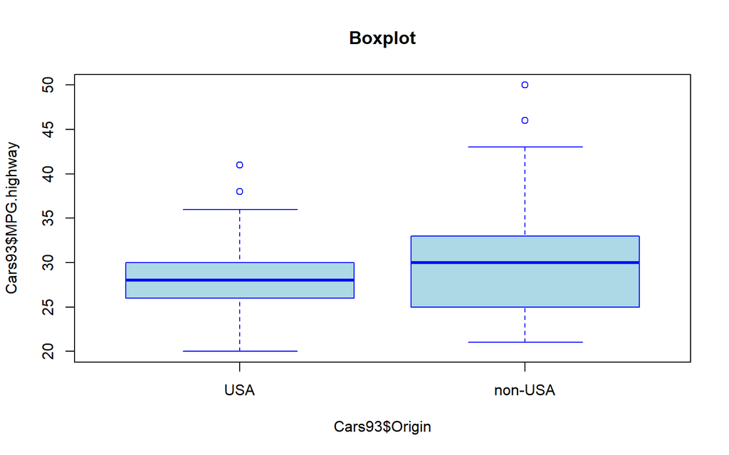

```r
B2<- boxplot(Cars93$MPG.highway~Cars93$Origin, col = "lightblue", main = "Boxplot", border = "blue")
```

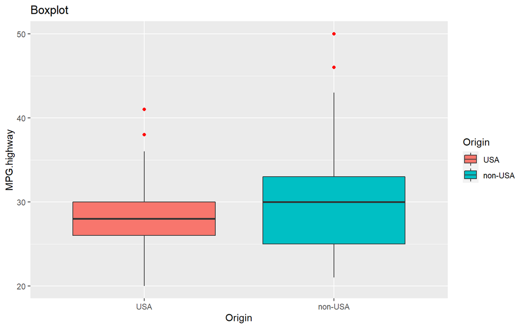

```r
GB2<- ggplot(data=Cars93, aes(x=Origin, y=MPG.highway, fill = Origin))+
  geom_boxplot(outlier.colour = "red")+
  ggtitle("Boxplot")+
  labs(x="Origin", fill = "Origin")
GB2
```